# Data 200: Lab 1a

Popular Baby Names

Author

## Preface

This file is a **Quarto document** and it allows us to combine text and code. By clicking **Render**, an html will be produced with all of the output from our code included. For today we will not worry about how the code, instead we will focus on our investigation.

Start by clicking `Render` and examine the html produced.

In this lab we will explore popular baby names for the state of California. This data comes from California birth certificates and is available on the [California Open Data Portal](https://data.ca.gov/dataset/most-popular-baby-names).

## Obtain and familiarize yourself with the data

This data is read in from a file called `california-popular-baby-names.csv` available online. We will save this data into an **object** called `baby-names`.

Let’s look at what is in our `baby_names` object.

```
# A tibble: 3,254 × 6
    Year Sex     Rank Name      Count Data_Revision_Date
   <dbl> <chr>  <dbl> <chr>     <dbl> <chr>
 1  1960 Female     1 SUSAN      3299 11/12/2025
 2  1960 Female     2 MARY       3248 11/12/2025
 3  1960 Female     3 KAREN      3156 11/12/2025
 4  1960 Female     4 CYNTHIA    2982 11/12/2025
 5  1960 Female     5 LISA       2839 11/12/2025
 6  1960 Female     6 LINDA      2807 11/12/2025
 7  1960 Female     7 DEBRA      2692 11/12/2025
 8  1960 Female     8 PATRICIA*  2668 11/12/2025
 9  1960 Female     9 DEBORAH    2490 11/12/2025
10  1960 Female    10 SANDRA     2404 11/12/2025
# ℹ 3,244 more rows
```

This dataset has 6 columns and 3,254 rows in total, which would be a lot to view at once, so only the first 10 are displayed.

For each year and specified sex at birth this data contains the 25 most popular baby first names and counts. We have data for each year from 1960 to 2024.

Let’s use this data to explore some questions.

### Question 1

What were the 5 most popular baby names in 2024?

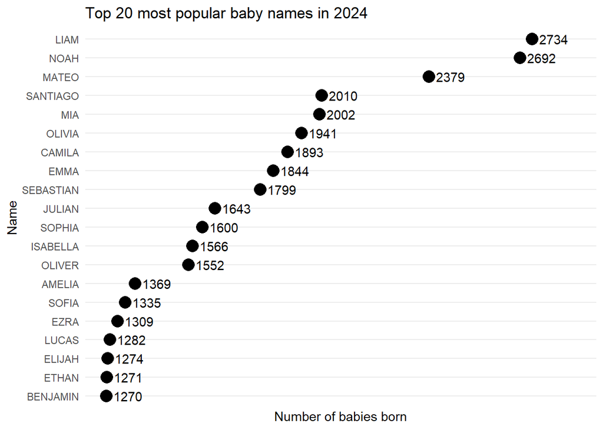

### Question 2

What were the 5 most popular baby names in the year you were born? To investigate this we will change the code, specifically the line that says `year_to_plot <- 2024`. Change the “2024” in the code chunk below in the Quarto document to the year you were born and render the html again.

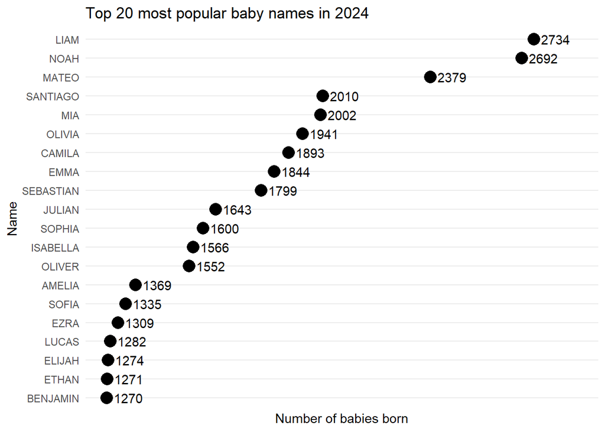

### Question 3

Below are all of the top 25 most popular baby names for each year from 1960-2024. Is your name in the list?

```
  [1] "AARON"       "ABIGAIL"     "ADAM"        "ADRIAN"      "AIDEN"
  [6] "ALEXA"       "ALEXANDER"   "ALEXANDRA"   "ALEXIS"      "ALLISON"
 [11] "ALYSSA"      "AMANDA"      "AMBER"       "AMELIA"      "AMY"
 [16] "ANDREA"      "ANDREW"      "ANGEL"       "ANGELA"      "ANGELINA"
 [21] "ANTHONY"     "ARIA"        "ASHLEY"      "AUDREY"      "AURORA"
 [26] "AUSTIN"      "AVA"         "AVERY"       "BARBARA"     "BELLA"
 [31] "BENJAMIN"    "BRANDON"     "BRIAN"       "BRIANNA"     "BRITTANY"
 [36] "CAMILA"      "CARLOS"      "CAROL"       "CHARLES"     "CHARLOTTE"
 [41] "CHELSEA"     "CHERYL"      "CHLOE"       "CHRISTIAN"   "CHRISTIN*"
 [46] "CHRISTINA"   "CHRISTOP*"   "CHRISTOPHER" "CRYSTAL"     "CYNTHIA"
 [51] "DANIEL"      "DANIELLE"    "DAVID"       "DAWN"        "DEBORAH"
 [56] "DEBRA"       "DENISE"      "DESTINY"     "DIANA"       "DIEGO"
 [61] "DONALD"      "DONNA"       "DYLAN"       "ELENA"       "ELIANA"
 [66] "ELIAS"       "ELIJAH"      "ELIZABET*"   "ELIZABETH"   "ELLA"
 [71] "EMILY"       "EMMA"        "ERIC"        "ERIN"        "ETHAN"
```

[output cut: 27 more lines]

### Question 4

What are the top 5 most popular baby names overall from all babies born between 1960-2024?

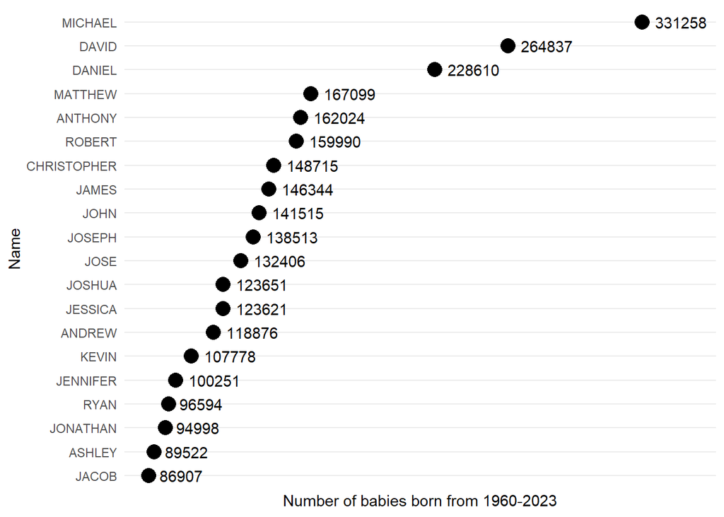

## Correcting truncated names

If you look into the [data dictionary](https://data.ca.gov/dataset/most-popular-baby-names/resource/a99404d8-e3b6-455c-9916-41075f001862) it says: *Names in records from data years 1960 through 1977 are truncated to 8 characters, and 1978 through 2017 are truncated to 12 characters.* *For example, the names CHRISTINA, CHRISTINE, and CHRISTIN would all be included in CHRISTIN*.*

When we look at names across the entire time period we may get different results if we truncated all names to 8 characters. This truncation is accounted for in the plot below.

### Question 5

Did the top 5 most popular baby names change once we corrected for inconsistent truncation of long names?

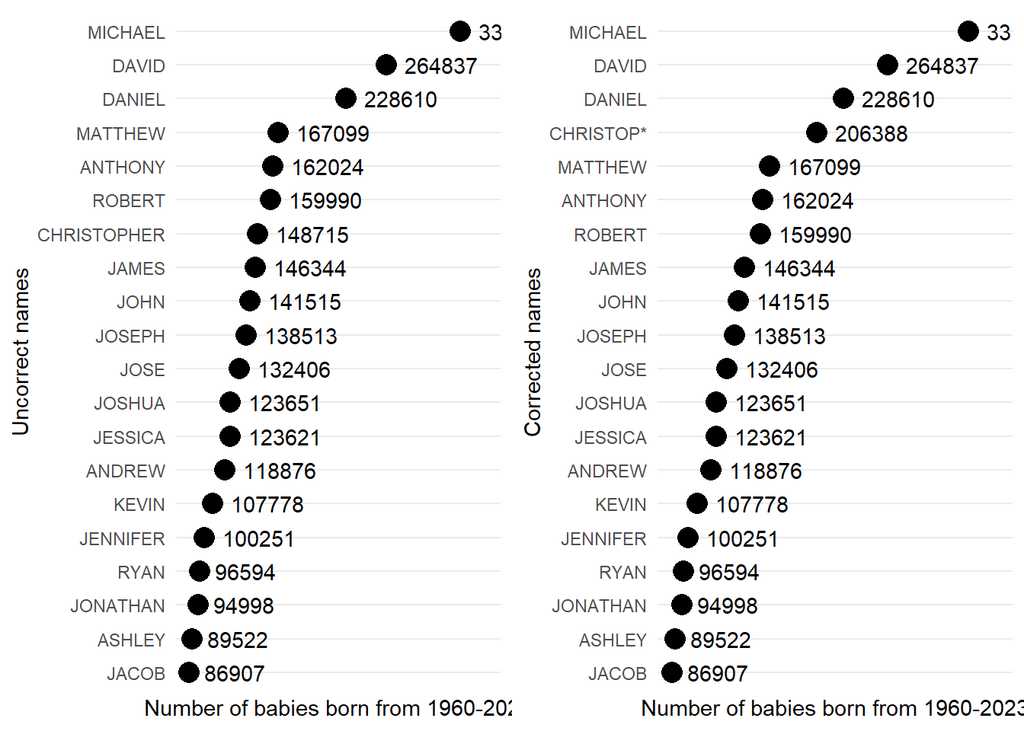

## 5 most popular baby names over the years

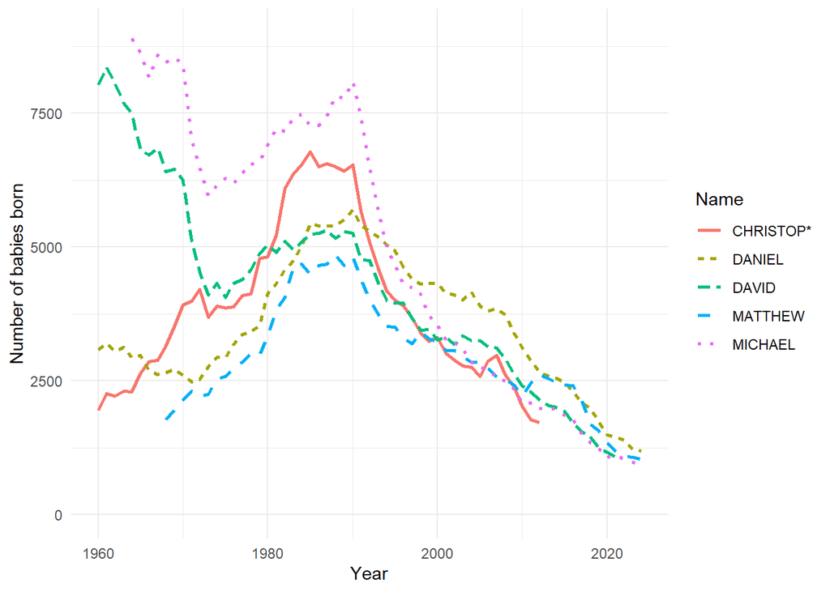

### Question 6

Did the most popular name in 1960 stay the most popular? If not, approximately what year did a different name become more popular and what was it?

### Question 7

Notice that the line for the name “Matthew” does not start until approximately the year 1968. Why do you think that is?